# From Regression to Machine Learning in R

Simon Schwab[^1]

15/04/2021

# About this notebook

This R notebook is a tutorial that complements my talk “From regression to machine learning in R”.

The goals are:

- Learn the first steps in machine learning in R
- Data reading and data management
- Visualization and descriptive statistics
- Showcase with linear regression (CDC data on blood pressure)
- Showcase with logistic regression (Wisconsin Breast Cancer Database)

# Install packages

```r
# install.packages("ggplot2")
# install.packages("reshape2")
# install.packages("cowplot")
# install.packages("car")
# install.packages("caret")
# install.packages("testit")
# install.packages("imbalance")
# install.packages("biostatUZH", repos = "http://R-Forge.R-project.org")
```

# Load libraries

```r
library(ggplot2)
library(reshape2)
library(cowplot)
library(car)
library(caret)
library(testit)
library(imbalance)
library(biostatUZH)
library(pROC)
```

# Case study 1: Predicting blood pressure in a CDC dataset by multiple linear regression

Goals:

- Develop and improve a linear model to predict blood pressure from a set of variables using linear regression.

Data:

- 1,475 patients with 9 variables (age, height, BMI, smoking status, etc).
- Real-world data by a CDC project NHANES (National Health and Nutrition Examination Survey).
- https://wwwn.cdc.gov/nchs/nhanes/Default.aspx

## Reading data

```r
COLORS = c("#00ba70", "#e50056")
cdc = read.csv("NHANES.csv")
N = nrow(cdc)
cdc[1:5,]
```

|  | systolic | weight | height | bmi | waist | age | diabetes | smoker | fastfood |
| --- | --- | --- | --- | --- | --- | --- | --- | --- | --- |
| 1 | 100 | 98.6 | 172.0 | 33.3 | 120.4 | 43 | 0 | 1 | 5 |
| 2 | 112 | 96.9 | 186.0 | 28.0 | 107.8 | 57 | 0 | 0 | 0 |
| 3 | 134 | 108.2 | 154.4 | 45.4 | 120.3 | 38 | 0 | 1 | 2 |
| 4 | 108 | 84.8 | 168.9 | 29.7 | 109.0 | 75 | 0 | 0 | 1 |
| 5 | 128 | 97.0 | 175.3 | 31.6 | 111.1 | 42 | 0 | 1 | 1 |

## Data preparation

```r
new = rep("No", N)
new[cdc$diabetes == 1] = "Yes"
cdc$diabetes = factor(new, levels = c("No", "Yes"))

new = rep("No", N)
new[cdc$smoker == 1] = "Yes"
cdc$smoker = factor(new, levels = c("No", "Yes"))
```

## Exploring the data

```r
summary(cdc)
```

```
    systolic         weight           height           bmi            waist            age        diabetes   smoker
 Min.   : 80.0   Min.   : 29.10   Min.   :141.2   Min.   :13.40   Min.   : 56.2   Min.   :20.00   No :1265   No :770
 1st Qu.:114.0   1st Qu.: 69.15   1st Qu.:163.8   1st Qu.:24.10   1st Qu.: 88.4   1st Qu.:34.00   Yes: 210   Yes:705
 Median :122.0   Median : 81.00   Median :170.3   Median :27.90   Median : 98.9   Median :49.00
 Mean   :124.7   Mean   : 83.56   Mean   :170.2   Mean   :28.79   Mean   :100.0   Mean   :48.89
 3rd Qu.:134.0   3rd Qu.: 94.50   3rd Qu.:176.8   3rd Qu.:32.10   3rd Qu.:109.5   3rd Qu.:62.00
 Max.   :224.0   Max.   :203.50   Max.   :200.4   Max.   :62.00   Max.   :176.0   Max.   :80.00
    fastfood
 Min.   : 0.00
 1st Qu.: 0.00
 Median : 1.00
 Mean   : 2.14
 3rd Qu.: 3.00
 Max.   :22.00
```

## Data visualization

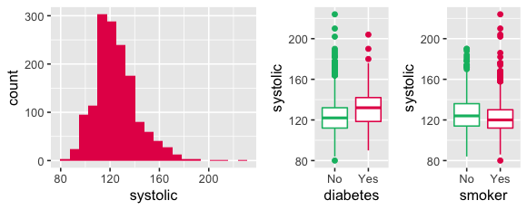

```r
p1 = ggplot(cdc, aes(x=systolic)) +
  geom_histogram(fill = COLORS[2], bins = 20)

p2 = ggplot(cdc, aes(y=systolic, x=diabetes, color=diabetes)) +
  geom_boxplot() +
  theme(legend.position = "none") +
  scale_color_manual(values = COLORS)

p3 = ggplot(cdc, aes(y=systolic, x=smoker, color=smoker)) +
  geom_boxplot() +
  theme(legend.position = "none") +
  scale_color_manual(values = COLORS)

plot_grid(p1, p2, p3, nrow=1, ncol=3, rel_widths = c(2, 1, 1))
```

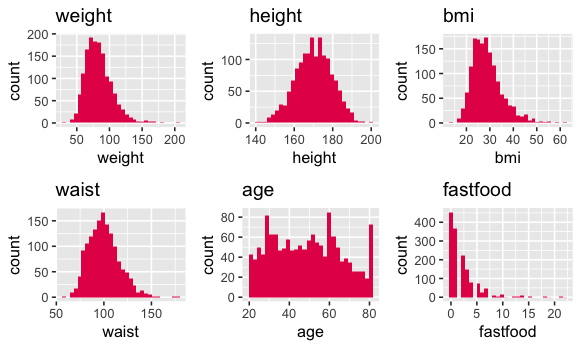

```r
p = list()
cols = c(2:6,9)
for (i in 1:6) {
  varName = names(cdc)[cols[i]]
  p[[i]] = ggplot(cdc, aes_string(x=varName)) +
    geom_histogram(fill = COLORS[2], bins = 30) + ggtitle(varName)
}

plot_grid(plotlist = p, nrow=2, ncol=3, rel_widths = c(1, 1, 1))
```

## Splitting the data into a training and testing set

```r
set.seed(1103)
idx = sample(N, round(0.75*N), replace = FALSE)
cdc.train = cdc[idx,]
cdc.test = cdc[-idx,]

assert(nrow(cdc.train) + nrow(cdc.test) == N)
```

## Mean centering variables

- When data transformations are performed they should be explained in the methods section
- Should be applied to the whole dataset (training and testing)

```r
meanAge = mean(cdc.train$age)

cdc.train$age = cdc.train$age - meanAge
cdc.test$age = cdc.test$age - meanAge

summary(cdc.train$age)
```

```
    Min.  1st Qu.   Median     Mean  3rd Qu.     Max.
-28.9033 -14.9033  -0.9033   0.0000  14.0967  31.0967
```

## Fitting the linear regression

```r
fit1 = lm(systolic ~ age, data=cdc.train)
summary(fit1)
```

```
Call:
lm(formula = systolic ~ age, data = cdc.train)

Residuals:
    Min      1Q  Median      3Q     Max
-41.704 -10.563  -0.877   8.523  99.108

Coefficients:
             Estimate Std. Error t value Pr(>|t|)
(Intercept) 124.44665    0.48254  257.90   <2e-16 ***
age           0.40615    0.02808   14.46   <2e-16 ***
---
Signif. codes:  0 ‘***’ 0.001 ‘**’ 0.01 ‘*’ 0.05 ‘.’ 0.1 ‘ ’ 1

Residual standard error: 16.05 on 1104 degrees of freedom
Multiple R-squared:  0.1593,    Adjusted R-squared:  0.1585
F-statistic: 209.2 on 1 and 1104 DF,  p-value: < 2.2e-16
```

## Residual analysis: accessing the largest residuals

$$\text{Residual: } e_i = y_i - \hat{y_i}$$

```r
sort(fit1$residuals, decreasing = TRUE)[1:10]
```

```
     859     1293      805     1120      360      486      867      315      761      122
99.10790 60.70174 57.39096 56.98481 51.45251 51.07713 50.92327 49.92021 48.17250 46.41868
```

```r
idx = which.max(fit1$residuals)
sprintf("Actual systolic pressure was %.0f but we estimated %.0f", cdc.train$systolic[idx], fit1$fitted.values[idx])
```

```
[1] "Actual systolic pressure was 224 but we estimated 125"
```

## Model using all variables

```r
fit2 = lm(systolic ~ ., data=cdc.train)
summary(fit2)
```

```
Call:
lm(formula = systolic ~ ., data = cdc.train)

Residuals:
    Min      1Q  Median      3Q     Max
-41.634 -10.009  -0.629   8.252 100.925

Coefficients:
             Estimate Std. Error t value Pr(>|t|)
(Intercept) 195.21693   39.18909   4.981 7.33e-07 ***
weight        0.60709    0.23449   2.589  0.00975 **
height       -0.44953    0.22960  -1.958  0.05050 .
bmi          -1.46649    0.67730  -2.165  0.03059 *
waist        -0.03827    0.09703  -0.394  0.69335
age           0.41705    0.03694  11.289  < 2e-16 ***
diabetesYes   2.77921    1.46426   1.898  0.05795 .
smokerYes     0.61677    1.04717   0.589  0.55599
fastfood      0.19009    0.17218   1.104  0.26984
---
Signif. codes:  0 ‘***’ 0.001 ‘**’ 0.01 ‘*’ 0.05 ‘.’ 0.1 ‘ ’ 1

Residual standard error: 15.92 on 1097 degrees of freedom
Multiple R-squared:  0.178, Adjusted R-squared:  0.1721
F-statistic:  29.7 on 8 and 1097 DF,  p-value: < 2.2e-16
```

## Residuals

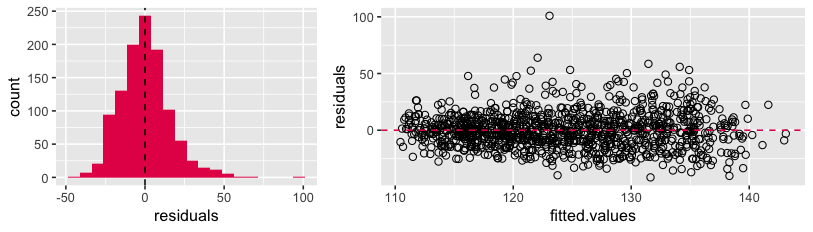

```r
d = data.frame(residuals = fit2$residuals)
d$fitted.values = fit2$fitted.values

p1 = ggplot(d, aes(x=residuals)) +
  geom_histogram(fill = COLORS[2], bins = 20) +
  geom_vline(xintercept=mean(d$residuals), linetype="dashed", color = "black")

p2 = ggplot(d, aes(x=fitted.values, y=residuals)) +
  geom_point(shape=1, size=2) +
  geom_hline(yintercept=0, linetype="dashed", color = COLORS[2])

plot_grid(p1, p2, nrow=1, ncol=2, rel_widths = c(1, 1.5))
```

## Checking Multicolinearity

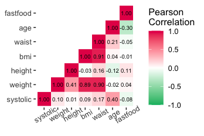

```r
cols = c(1:6,9)
r = cor(cdc.train[,cols])

r[upper.tri(r)] = NA
d = melt(r)
ggplot(d, aes(x=Var1, y=Var2, fill=value)) +
  geom_tile() +
  scale_fill_gradient2(low = COLORS[1], high = COLORS[2], mid = "white",
                       na.value = "white", midpoint = 0, limit = c(-1,1),
                       name="Pearson\nCorrelation") +
  theme(panel.background=element_rect(fill="white"),
        axis.title = element_blank(),
        axis.text.x = element_text(angle = 30)) +
  geom_text(aes(Var1, Var2, label = ifelse(is.na(value), "", sprintf("%.2f",value))), color = "black", size = 2.3)
```

Variance Inflation Factor (VIF) is a measure of how much the variance of the estimated regression coefficient for that variable is inflated by the existence of correlation among the predictor variables in the model.

- A Cut-off of VIF > 5 is commonly used

```r
vif(fit2)
```

```
   weight    height       bmi     waist       age  diabetes    smoker  fastfood
98.103337 19.508020 81.162473 10.434871  1.759057  1.133795  1.191781  1.113211
```

```r
fit3 = lm(systolic ~ weight + age, data=cdc.train)
summary(fit3)
```

```
Call:
lm(formula = systolic ~ weight + age, data = cdc.train)

Residuals:
    Min      1Q  Median      3Q     Max
-42.355 -10.151  -0.809   8.359 101.533

Coefficients:
             Estimate Std. Error t value Pr(>|t|)
(Intercept) 116.96118    2.03081  57.593  < 2e-16 ***
weight        0.09000    0.02373   3.793 0.000157 ***
age           0.40802    0.02792  14.616  < 2e-16 ***
---
Signif. codes:  0 ‘***’ 0.001 ‘**’ 0.01 ‘*’ 0.05 ‘.’ 0.1 ‘ ’ 1

Residual standard error: 15.95 on 1103 degrees of freedom
Multiple R-squared:  0.1701,    Adjusted R-squared:  0.1686
F-statistic: 113.1 on 2 and 1103 DF,  p-value: < 2.2e-16
```

```r
tab = tableRegression(fit3, xtable = FALSE)
names(tab)[2:3] = c("95%-confidence interval", "p-value")
print(tab)
```

|  | Coefficient | 95%-confidence interval | p-value |
| --- | --- | --- | --- |
| Intercept | 116.96 | from 112.98 to 120.95 | < 0.0001 |
| weight | 0.09 | from 0.04 to 0.14 | 0.0002 |
| age | 0.41 | from 0.35 to 0.46 | < 0.0001 |

## Influental point analysis

- The goal of Influential Point Analysis is to identify extreme values in the multidimensional space
- We use Cook’s distance function to identify influential points
- $D_i$ is sum of all the changes in the regression model when an observation $i$ is removed from it
- For an observation to be flagged, its Cook’s distance should be greater than

$$\text{Cut-off value t} = \frac{4}{n - k - 1}$$

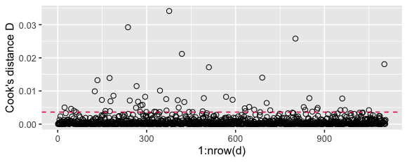

```r
d = data.frame(cook = cooks.distance(fit3))
t = 4 / (nrow(cdc.train) - 3 - 1)

ggplot(d, aes(x=1:nrow(d), y=cook)) +
  geom_point(shape=1, size=2) +
  geom_hline(yintercept=t, linetype="dashed", color = COLORS[2]) +
  ylab("Cook's distance D")
```

```r
idx = d > t
# sum(idx) / nrow(cdc.train)
cdc.train.ex = subset(cdc.train, subset = !idx)
```

```r
fit4 = lm(systolic ~ weight + age, data=cdc.train.ex)
summary(fit4)
```

```
Call:
lm(formula = systolic ~ weight + age, data = cdc.train.ex)

Residuals:
    Min      1Q  Median      3Q     Max
-38.648  -9.170  -0.086   8.495  45.129

Coefficients:
             Estimate Std. Error t value Pr(>|t|)
(Intercept) 113.96552    1.85844  61.323  < 2e-16 ***
weight        0.11388    0.02189   5.203 2.36e-07 ***
age           0.39503    0.02468  16.006  < 2e-16 ***
---
Signif. codes:  0 ‘***’ 0.001 ‘**’ 0.01 ‘*’ 0.05 ‘.’ 0.1 ‘ ’ 1

Residual standard error: 13.5 on 1045 degrees of freedom
Multiple R-squared:  0.2128,    Adjusted R-squared:  0.2113
F-statistic: 141.3 on 2 and 1045 DF,  p-value: < 2.2e-16
```

```r
tab = tableRegression(fit4, xtable = FALSE)
names(tab)[2:3] = c("95%-confidence interval", "p-value")
print(tab)
```

|  | Coefficient | 95%-confidence interval | p-value |
| --- | --- | --- | --- |
| Intercept | 113.97 | from 110.32 to 117.61 | < 0.0001 |
| weight | 0.11 | from 0.07 to 0.16 | < 0.0001 |
| age | 0.40 | from 0.35 to 0.44 | < 0.0001 |

## Model comparison

AIC (Akaike information criterion) quantifies how well the model did in predicting explaining the variability in the data (goodness of fit)

- Can compare multiple models
- Need to have the same data
- Includes a penalty for each additional variable
- The lower the AIC, the better

```r
AIC(fit1, fit2, fit3)
```

|  | df | AIC |
| --- | --- | --- |
| fit1 | 3 | 9282.233 |
| fit2 | 10 | 9271.298 |
| fit3 | 4 | 9269.898 |

## Prediction of a single new patient

```r
predict(fit4,
        newdata=data.frame(weight=74, age=41-meanAge),
        interval = "prediction")
```

```
       fit      lwr      upr
1 119.2707 92.76901 145.7723
```

## Validation with the test dataset

```r
pred1 = as.data.frame(predict(fit3, newdata=cdc.test,  interval = "prediction"))
pred1$actual = cdc.test$systolic
print(pred1)
```

|  | fit | lwr | upr | actual |
| --- | --- | --- | --- | --- |
| 8 | 112.4404 | 81.07180 | 143.8090 | 124 |
| 10 | 134.0921 | 102.67734 | 165.5069 | 138 |
| 16 | 134.9413 | 103.56328 | 166.3193 | 114 |
| 19 | 132.1391 | 100.78683 | 163.4914 | 122 |
| 29 | 118.3866 | 87.04505 | 149.7282 | 116 |
| 31 | 118.6926 | 87.35512 | 150.0300 | 166 |
| 32 | 122.5598 | 91.23759 | 153.8820 | 108 |
| 33 | 122.1697 | 90.85596 | 153.4835 | 128 |
| 35 | 123.8648 | 92.54356 | 155.1861 | 136 |
| 40 | 124.7558 | 93.39986 | 156.1117 | 142 |

[output cut: 359 more lines]

## Evaluating performence: Root mean squared error and R-Square

```r
RMSE = sqrt(sum( (pred1$actual - pred1$fit)^2 ) / nrow(pred1) )
R2 = 1 - sum((pred1$actual - pred1$fit)^2) / sum((pred1$actual - mean(pred1$actual))^2)
sprintf("RMSE = %.2f; R-squared = %.3f", RMSE, R2)
```

```
[1] "RMSE = 16.29; R-squared = 0.178"
```

## Further improving the model

- Add more variables
- Clinical knowledge should be included in variable selection
- Are there non-linear relationships?
- Are there interactions?

# Case study 2: Logistic regression with Wisconsin cancer data

Breast Cancer Wisconsin (Diagnostic) Data Set

- Features are computed from a digitized image of a fine needle aspirate (FNA) of a breast mass. They describe characteristics of the cell nuclei present in the image.
- https://www.kaggle.com/uciml/breast-cancer-wisconsin-data

## Reading data

```r
COLORS = c("#00ba70", "#e50056")
cancer = read.csv("cancer.csv")
N = nrow(cancer)
# remove first last column
cancer = cancer[,c(-1, -33)]
cancer$diagnosis = as.factor(cancer$diagnosis)
cancer[1:5,]
```

|  | diagnosis | radius_mean | texture_mean | perimeter_mean | area_mean | smoothness_mean | compactness_mean | concavity_mean | concave.points_mean | symmetry_mean | fractal_dimension_mean | radius_se | texture_se | perimeter_se | area_se | smoothness_se | compactness_se | concavity_se | concave.points_se | symmetry_se | fractal_dimension_se | radius_worst | texture_worst | perimeter_worst | area_worst | smoothness_worst | compactness_worst | concavity_worst | concave.points_worst | … |
| --- | --- | --- | --- | --- | --- | --- | --- | --- | --- | --- | --- | --- | --- | --- | --- | --- | --- | --- | --- | --- | --- | --- | --- | --- | --- | --- | --- | --- | --- | --- |
| 1 | M | 17.99 | 10.38 | 122.80 | 1001.0 | 0.11840 | 0.27760 | 0.3001 | 0.14710 | 0.2419 | 0.07871 | 1.0950 | 0.9053 | 8.589 | 153.40 | 0.006399 | 0.04904 | 0.05373 | 0.01587 | 0.03003 | 0.006193 | 25.38 | 17.33 | 184.60 | 2019.0 | 0.1622 | 0.6656 | 0.7119 | 0.2654 | … |
| 2 | M | 20.57 | 17.77 | 132.90 | 1326.0 | 0.08474 | 0.07864 | 0.0869 | 0.07017 | 0.1812 | 0.05667 | 0.5435 | 0.7339 | 3.398 | 74.08 | 0.005225 | 0.01308 | 0.01860 | 0.01340 | 0.01389 | 0.003532 | 24.99 | 23.41 | 158.80 | 1956.0 | 0.1238 | 0.1866 | 0.2416 | 0.1860 | … |
| 3 | M | 19.69 | 21.25 | 130.00 | 1203.0 | 0.10960 | 0.15990 | 0.1974 | 0.12790 | 0.2069 | 0.05999 | 0.7456 | 0.7869 | 4.585 | 94.03 | 0.006150 | 0.04006 | 0.03832 | 0.02058 | 0.02250 | 0.004571 | 23.57 | 25.53 | 152.50 | 1709.0 | 0.1444 | 0.4245 | 0.4504 | 0.2430 | … |
| 4 | M | 11.42 | 20.38 | 77.58 | 386.1 | 0.14250 | 0.28390 | 0.2414 | 0.10520 | 0.2597 | 0.09744 | 0.4956 | 1.1560 | 3.445 | 27.23 | 0.009110 | 0.07458 | 0.05661 | 0.01867 | 0.05963 | 0.009208 | 14.91 | 26.50 | 98.87 | 567.7 | 0.2098 | 0.8663 | 0.6869 | 0.2575 | … |
| 5 | M | 20.29 | 14.34 | 135.10 | 1297.0 | 0.10030 | 0.13280 | 0.1980 | 0.10430 | 0.1809 | 0.05883 | 0.7572 | 0.7813 | 5.438 | 94.44 | 0.011490 | 0.02461 | 0.05688 | 0.01885 | 0.01756 | 0.005115 | 22.54 | 16.67 | 152.20 | 1575.0 | 0.1374 | 0.2050 | 0.4000 | 0.1625 | … |

## Histograms of all variables

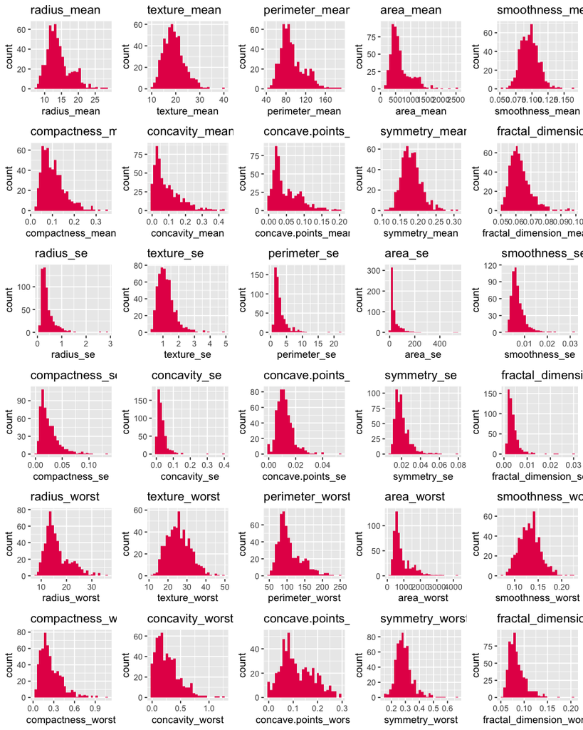

```r
p = list()
cols = c(2:31)
for (i in 1:30) {
  varName = names(cancer)[cols[i]]
  p[[i]] = ggplot(cancer, aes_string(x=varName)) +
    geom_histogram(fill = COLORS[2], bins = 30) + ggtitle(varName)
}

plot_grid(plotlist = p, nrow=6, ncol=5, rel_widths = c(1, 1, 1))
```

## Data transformation

```r
for (i in 2:ncol(cancer)) {
  cancer[,i] = as.numeric(scale(cancer[,i], scale = TRUE, center = TRUE))
}
```

## Splitting the data

```r
set.seed(1103)
idx = sample(N, round(0.75*N), replace = FALSE)
cancer.train.imbal = cancer[idx,]
cancer.test = cancer[-idx,]
assert(nrow(cancer.train.imbal) + nrow(cancer.test) == N)
```

## Synthetic Minority Oversampling Technique (SMOTE)

Ideally the class distribution in the training data should be uniform, but this is not always the case (class imbalance)

- Often the minority class is of interest
- However, because there are fewer examples for the minority class, it is more challenging for a model to effectively learn the patterns of the minority class
- Can add bias, e.g. too optimistic predictive accuracy

How to address class imbalance

- Collect more data
- Resampling strategies, e.g. with the package “imbalance”, see https://rpubs.com/yoompubs/467234

```r
#vignette("imbalance")
set.seed(1103)
nr = table(cancer.train.imbal$diagnosis)[1] - table(cancer.train.imbal$diagnosis)[2]
cancer.train.synth = mwmote(cancer.train.imbal, numInstances = nr, classAttr = "diagnosis")
cancer.train = rbind(cancer.train.imbal, cancer.train.synth)
summary(cancer.train$diagnosis)
```

```
  B   M
269 269
```

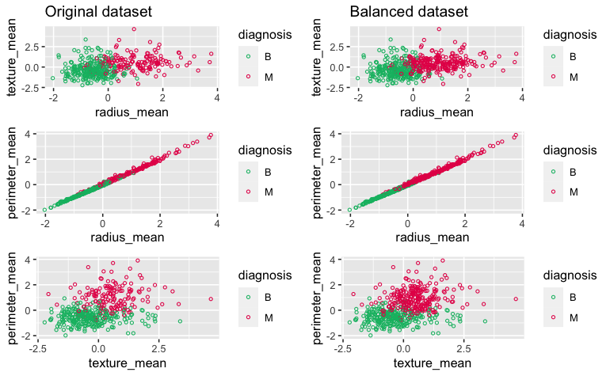

```r
p = list()
myVars = names(cancer)[2:4]
C = combn(1:3,2)

m = 1
for (i in seq(1,6,2)) {
  p[[i]] = ggplot(cancer.train.imbal, aes_string(x=myVars[C[1,m]], y=myVars[C[2,m]], color="diagnosis")) +
    geom_point(shape=1, size=1) +
    scale_color_manual(values = COLORS)
  if (i==1) {p[[i]] = p[[i]] + ggtitle("Original dataset")}

  p[[i+1]] = ggplot(cancer.train, aes_string(x=myVars[C[1,m]], y=myVars[C[2,m]], color="diagnosis")) +
    geom_point(shape=1, size=1) +
    scale_color_manual(values = COLORS)
  if (i==1) {p[[i+1]] = p[[i+1]] + ggtitle("Balanced dataset")}

  m = m + 1
}

plot_grid(plotlist = p, nrow=3, ncol=2)
```

## Dealing with multicolinearity

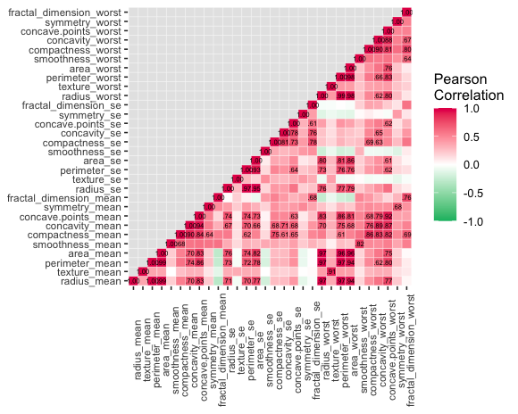

```r
R = cor(cancer.train[,2:ncol(cancer.train)])
R[upper.tri(R)] = NA
d = melt(R)
ggplot(d, aes(x=Var1, y=Var2, fill=value)) +
  geom_tile(colour = "white") +
  scale_fill_gradient2(low = COLORS[1], high = COLORS[2], mid = "white",
                       na.value = "gray90", midpoint = 0, limit = c(-1,1),
                       name="Pearson\nCorrelation") +
  theme(panel.background=element_rect(fill="white"),
        axis.title = element_blank(),
        axis.text = element_text(size=8),
        axis.text.x = element_text(angle = 90)) +
  geom_text(aes(Var1, Var2,
                label = ifelse(is.na(value) | (value < 0.60 & value > -0.60),
                                           "", sub("^(-?)0.", "\\1.", sprintf("%.2f", value)))), color = "black", size = 1.8)
```

## How to Deal with Multicollinearity

- Remove some of the highly correlated independent variables
- Linearly combine the variables, such as adding them together
- Perform an analysis designed for highly correlated variables, such as principal components analysis or partial least squares regression
- LASSO and Ridge regression are advanced forms of regression analysis that can handle multicollinearity

https://statisticsbyjim.com/regression/multicollinearity-in-regression-analysis/

```r
R = cor(cancer.train[,2:ncol(cancer.train)])
list = findCorrelation(R, cutoff = 0.60, names = TRUE )
cancer.train.subset = cancer.train[, !(names(cancer) %in% list)]
```

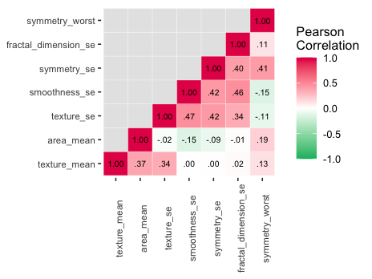

```r
M = cor(cancer.train.subset[,2:ncol(cancer.train.subset)])
M[upper.tri(M)] = NA
d = melt(M)
ggplot(d, aes(x=Var1, y=Var2, fill=value)) +
  geom_tile(colour = "white") +
  scale_fill_gradient2(low = COLORS[1], high = COLORS[2], mid = "white",
                       na.value = "gray90", midpoint = 0, limit = c(-1,1),
                       name="Pearson\nCorrelation") +
  theme(panel.background=element_rect(fill="white"),
        axis.title = element_blank(),
        axis.text = element_text(size=8),
        axis.text.x = element_text(angle = 90)) +
  geom_text(aes(Var1, Var2,
                #label = ifelse(is.na(value) | (value < 0.60 & value > -0.60),
                label = ifelse(is.na(value), "",
                               sub("^(-?)0.", "\\1.", sprintf("%.2f", value)))), color = "black", size = 2.5)
```

## Training the model

```r
fit1 = glm(diagnosis ~ ., family=binomial(), data=cancer.train.subset)
```

```
glm.fit: fitted probabilities numerically 0 or 1 occurred
```

```r
# fit2 = glm(diagnosis ~ radius_mean + texture_mean + texture_se + smoothness_worst +
#              symmetry_worst, family=binomial(), data=data.train.subset)
#fit3 = glm(diagnosis ~ radius_mean + smoothness_worst, family=binomial(), data=data.train.subset)
summary(fit1)
```

```
Call:
glm(formula = diagnosis ~ ., family = binomial(), data = cancer.train.subset)

Deviance Residuals:
    Min       1Q   Median       3Q      Max
-2.5521  -0.1199  -0.0005   0.0365   3.9868

Coefficients:
                     Estimate Std. Error z value Pr(>|z|)
(Intercept)           0.03905    0.26360   0.148  0.88224
texture_mean          1.15128    0.29574   3.893 9.91e-05 ***
area_mean             6.37504    0.76362   8.348  < 2e-16 ***
texture_se            0.35525    0.38837   0.915  0.36034
smoothness_se         1.22053    0.41916   2.912  0.00359 **
symmetry_se          -2.01409    0.40357  -4.991 6.02e-07 ***
fractal_dimension_se  0.30012    0.40328   0.744  0.45675
symmetry_worst        3.12346    0.43781   7.134 9.73e-13 ***
---
Signif. codes:  0 ‘***’ 0.001 ‘**’ 0.01 ‘*’ 0.05 ‘.’ 0.1 ‘ ’ 1

(Dispersion parameter for binomial family taken to be 1)

    Null deviance: 745.83  on 537  degrees of freedom
Residual deviance: 133.60  on 530  degrees of freedom
AIC: 149.6

Number of Fisher Scoring iterations: 8
```

```r
tableOR(fit1, latex = FALSE, Wald = TRUE)
```

|  | OR | 95% CI | z value | p-value |
| --- | --- | --- | --- | --- |
| texture_mean | 3.16 | from 1.77 to 5.65 | 3.89 | < 0.0001 |
| area_mean | 587.01 | from 131.42 to 2622.01 | 8.35 | < 0.0001 |
| texture_se | 1.43 | from 0.67 to 3.05 | 0.91 | 0.36 |
| smoothness_se | 3.39 | from 1.49 to 7.71 | 2.91 | 0.004 |
| symmetry_se | 0.13 | from 0.06 to 0.29 | -4.99 | < 0.0001 |
| fractal_dimension_se | 1.35 | from 0.61 to 2.98 | 0.74 | 0.46 |
| symmetry_worst | 22.72 | from 9.63 to 53.60 | 7.13 | < 0.0001 |

## Check variable importance with AIC

```r
drop1(fit1)
```

[output not shown]

```
Single term deletions

Model:
diagnosis ~ texture_mean + area_mean + texture_se + smoothness_se +
    symmetry_se + fractal_dimension_se + symmetry_worst
                     Df Deviance    AIC
<none>                    133.60 149.60
texture_mean          1   151.01 165.01
area_mean             1   453.52 467.52
texture_se            1   134.45 148.45
smoothness_se         1   142.96 156.96
symmetry_se           1   159.18 173.18
fractal_dimension_se  1   134.09 148.09
symmetry_worst        1   240.51 254.51
```

```r
fit2 = glm(diagnosis ~ area_mean, family=binomial(), data=cancer.train.subset)
summary(fit2)
```

```
Call:
glm(formula = diagnosis ~ area_mean, family = binomial(), data = cancer.train.subset)

Deviance Residuals:
     Min        1Q    Median        3Q       Max
-3.14454  -0.39188  -0.02399   0.19198   2.75002

Coefficients:
            Estimate Std. Error z value Pr(>|z|)
(Intercept)   0.2865     0.1611   1.778   0.0753 .
area_mean     4.8532     0.4533  10.707   <2e-16 ***
---
Signif. codes:  0 ‘***’ 0.001 ‘**’ 0.01 ‘*’ 0.05 ‘.’ 0.1 ‘ ’ 1

(Dispersion parameter for binomial family taken to be 1)

    Null deviance: 745.83  on 537  degrees of freedom
Residual deviance: 290.32  on 536  degrees of freedom
AIC: 294.32

Number of Fisher Scoring iterations: 7
```

## Confusion matrix, sensitivity and specificity

```r
pred1 = predict(fit1, cancer.test, type = "response")
tab = table(cancer.test$diagnosis, ifelse(pred1 >= 0.5, 1, 0))
print(tab)
```

```
     0  1
  B 84  4
  M  6 48
```

$$Sensitivity = \frac{TP}{TP + FN} = \frac{48}{48 + 6} = 0.889 \\
Specificity = \frac{TN}{TN + FP} = \frac{84}{84 + 4} = 0.955$$

```r
pred2 = predict(fit2, cancer.test, type = "response")
tab = table(cancer.test$diagnosis, ifelse(pred2 >= 0.5, 1, 0))
print(tab)
```

```
     0  1
  B 74 14
  M  9 45
```

$$Sensitivity = \frac{TP}{TP + FN} = \frac{45}{45 + 9} = 0.833 \\
Specificity = \frac{TN}{TN + FP} = \frac{74}{74 + 14} = 0.841$$
## Calculate the propensities at different thresholds

```r
t = sort(rep(seq(0, 1, 0.10),2))
k = length(t)
tab = data.frame(sensitivity = rep(NA, k),
                 specificity = rep(NA, k),
                 threshold   = t,
                 model = rep(NA, k))

for ( i in seq(1,k,2) ) {
  tab$sensitivity[i] =  sum( pred1 >  t[i] & cancer.test$diagnosis=="M" ) / sum(cancer.test$diagnosis=="M")
  tab$specificity[i] =  sum( pred1 <= t[i] & cancer.test$diagnosis=="B" ) / sum(cancer.test$diagnosis=="B")
  tab$model[i] = "Model 1"

  tab$sensitivity[i+1] =  sum( pred2 >  t[i] & cancer.test$diagnosis=="M" ) / sum(cancer.test$diagnosis=="M")
  tab$specificity[i+1] =  sum( pred2 <= t[i] & cancer.test$diagnosis=="B" ) / sum(cancer.test$diagnosis=="B")
  tab$model[i+1] = "Model 2"
}

tab[1:5,]
```

|  | sensitivity | specificity | threshold | model |
| --- | --- | --- | --- | --- |
| 1 | 1.0000000 | 0.0000000 | 0.0 | Model 1 |
| 2 | 1.0000000 | 0.0000000 | 0.0 | Model 2 |
| 3 | 0.9814815 | 0.7613636 | 0.1 | Model 1 |
| 4 | 0.9814815 | 0.5340909 | 0.1 | Model 2 |
| 5 | 0.9629630 | 0.8863636 | 0.2 | Model 1 |

## Receiver operating characteristic Curve (ROC)

- ML algorithms are not binary decisions, we have probabilities that a patient belongs to a particular class
- Adjusting the cut-off value has an impact on sensitivity and specificity
- The ROC curve illustrates the inherent trade-off that exists between sensitivity and specificity
- The AUC (area under the curve) is the probability that a classifier ranks a randomly chosen positive instance above a randomly chosen negative instance
- The AUC ranges from 0.5 (no predictive value) to 1.0 (perfect classifier)

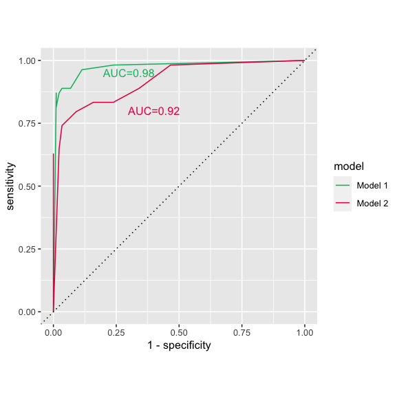

```r
myroc1 = roc(response = cancer.test$diagnosis, predictor = pred1) # from pROC package
myroc2 = roc(response = cancer.test$diagnosis, predictor = pred2)

ggplot(tab) +
  geom_line(aes(x=1-specificity, y=sensitivity, group=model, color=model)) +
  geom_abline(intercept=0, slope=1, linetype=3) + theme(aspect.ratio=1) +
  xlim(0,1) + ylim(0,1) +
  scale_color_manual(values = COLORS) +
  annotate("text", x = 0.3, y=0.95, label = sprintf("AUC=%.2f", myroc1$auc), color = COLORS[1]) +
  annotate("text", x = 0.4, y=0.80, label = sprintf("AUC=%.2f", myroc2$auc), color= COLORS[2])
```

# Figure for presentation front slide

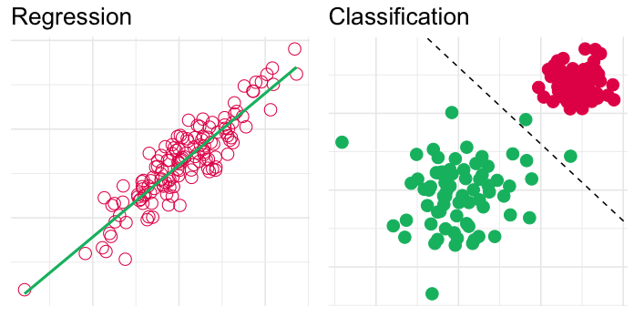

```r
set.seed(1103)
k = 140
data = data.frame(predictor = rnorm(k))
data$outcome = data$predictor*2 + 3 + rnorm(k)


p1 = ggplot(data, aes(y=outcome, x=predictor)) +
  geom_point(col=COLORS[2], size=4, shape=1) +
  geom_smooth(formula = y ~ x,method=lm, se=FALSE, fullrange=TRUE, col=COLORS[1]) +
  theme_minimal() +
  theme(axis.text = element_blank(),
        axis.title = element_blank(),
        title = element_text(size=15)) +
  ggtitle("Regression")

data = data.frame(predictor = c(rnorm(k/2, sd=2), rnorm(k/2, mean=7, sd=1)))
data$outcome = data$outcome = c(rnorm(k/2, sd=2), rnorm(k/2, mean=7, sd=1))
data$class = "B"
data$class[1:(k/2)] = "A"

p2 = ggplot(data, aes(y=outcome, x=predictor, color=class)) +
  geom_point(size=4) +
  geom_abline(intercept = 8, slope = -1, linetype = "dashed") +
  theme_minimal() +
  theme(axis.text = element_blank(),
        axis.title = element_blank(),
        title = element_text(size=15),
        legend.position = "none") +
  ggtitle("Classification") +
  scale_color_manual(values = COLORS)

plot_grid(p1, p2, nrow=1, ncol=2)
```

[^1]: University of Zurich, simon.schwab@uzh.ch